# Modelling depression with SHARE data - using survey weights

### 1.2.2 Unadjusted models - weighted models and comparsion with unweighted

```r
my.mod <- glm(eurodcat_imp ~ rcs(age_int_stand) + gender + region +
                       rcs(age_int_stand):region + rcs(age_int_stand):gender + gender:region ,
                                             data=share.data.w1, family="binomial",  x=TRUE, y=TRUE)

#save the spline terms in the complete data set for further use
share.data.w1 <- share.data.w1 %>% mutate(age1 = my.mod$x[,2],
                                                                    age2 = my.mod$x[,3],
                                                                    age3 = my.mod$x[,4],
                                                                    age4 = my.mod$x[,5])


# retrieve the location of knots used and assign them to Knots variable
Knots <- Hmisc::rcspline.eval(x = share.data.w1$age_int_stand, nk = 5, knots.only = TRUE)

#reproduces the spline values for age, expands for each integer value from 50 to 90
age = rcspline.eval(c(50:90)-50, knots=Knots)
age <- cbind.data.frame(age1=c(50:90)-50, age )
dimnames(age)[[2]] <- c("age1", "age2", "age3", "age4")






if(!is.null(my.mod$na.action)){
my.mod2 <- glm(eurodcat_imp ~ age1 + age2 + age3 + age4 + gender + region +
                      age1:region + age2:region + age3:region + age4:region +
                       age1:gender + age2:gender + age3:gender + age4:gender +
                       gender:region ,
                        data=share.data.w1[-my.mod$na.action,], family="binomial",  x=TRUE, y=TRUE)} else {
 my.mod2 <- glm(eurodcat_imp ~ age1 + age2 + age3 + age4 + gender + region +
                      age1:region + age2:region + age3:region + age4:region +
                       age1:gender + age2:gender + age3:gender + age4:gender +
                       gender:region ,
                        data=share.data.w1, family="binomial",  x=TRUE, y=TRUE)
}





#derive the data.frame containing the levels of the covariatee, where the probabilities of depression estimated by the model will be derived
data.grid <- expand.grid(age1=age[,1], gender=levels(share.data.w1$gender), region=levels(share.data.w1$region))
data.grid <- left_join(data.grid, age, by="age1" )

#data.grid <- filter(data.grid, is.element(region, c("Austria", "Spain", "Italy", "France", "Belgium", "Israel")))
data.grid.region <- data.grid


#defining also data grid for countries
data.grid.region <- expand.grid(age1=age[,1], gender=levels(share.data.w1$gender), region=levels(share.data.w1$region))
data.grid.region <- left_join(data.grid.region, age, by="age1" )




#derive the predicted probabilities
my.pred <- predict(my.mod2, newdata=data.grid, se.fit = TRUE, type="response")

#join the levels of the covariates and the predicted probabilities
my.pred.all <- cbind.data.frame(data.grid, my.pred)

#saving the estimates from the 2-way models
pred.age_unadjusted_region_rcs <- my.pred.all
```

```r
ggplot(my.pred.all, aes(age1+50, fit, color=gender)) + geom_line() + facet_wrap(region~., ncol=5) + labs(x="Age", y="Estimated probability of depression") + scale_color_manual(values=c("#4699dd","#ff3db7" )) + ggtitle("Unadjusted - (gender, region, rcs(age))") +
  geom_ribbon(aes(ymin = fit - 1.96*se.fit, ymax = fit + 1.96*se.fit), alpha = 0.2, linetype=0) +  theme_bw()


#my.pred.all %>% left_join(select(share.data.w1, starts_with("region")), by="region") %>% ggplot(aes(age1, fit, #color=gender))+ geom_point() + facet_grid(.~regionGroup) + labs(x="Age", y="Estimated probability of depression") + #scale_color_manual(values=c("#4699dd","#ff3db7" ))


anova(my.mod, test="Chi")
```

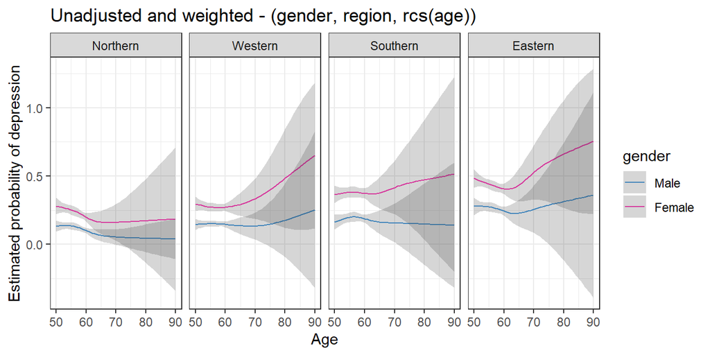

```r
 my.mod.w <- svyglm(eurodcat_imp ~ age1 + age2 + age3 + age4 + gender + region +
                      age1:region + age2:region + age3:region + age4:region +
                       age1:gender + age2:gender + age3:gender + age4:gender +
                       gender:region ,
                        design=dstrat, family="binomial",  x=TRUE, y=TRUE)




#derive the predicted probabilities
my.pred <- predict(my.mod.w, newdata=data.grid, se.fit = TRUE, type="response")
#join the levels of the covariates and the predicted probabilities
my.pred.all <- cbind.data.frame(data.grid, my.pred)

my.pred.all <- pred.age_unadjusted_region_rcs_w<- rename(my.pred.all, fit=response, se.fit = SE)
pred.age_unadjusted_region_rcs_w <- mutate(pred.age_unadjusted_region_rcs_w, residual.scale = 1)

pred.age_all <- rbind.data.frame(pred.age_unadjusted_region_rcs,pred.age_unadjusted_region_rcs_w)
pred.age_all <- mutate(pred.age_all, model=c(rep("Unadjusted \n rcs", nrow(pred.age_unadjusted_region_rcs)), rep("Unadjusted weighted \n rcs", nrow(pred.age_unadjusted_region_rcs))))

#saving the estimates from the 2-way models
pred.age_unadjusted_region_rcs <- my.pred.all




ggplot(my.pred.all, aes(age1+50, fit, color=gender)) + geom_line() + facet_wrap(region~., ncol=5) + labs(x="Age", y="Estimated probability of depression") + scale_color_manual(values=c("#4699dd","#ff3db7" )) + ggtitle("Unadjusted and weighted - (gender, region, rcs(age))") +
  geom_ribbon(aes(ymin = fit - 1.96*se.fit, ymax = fit + 1.96*se.fit), alpha = 0.2, linetype=0) +  theme_bw()
```

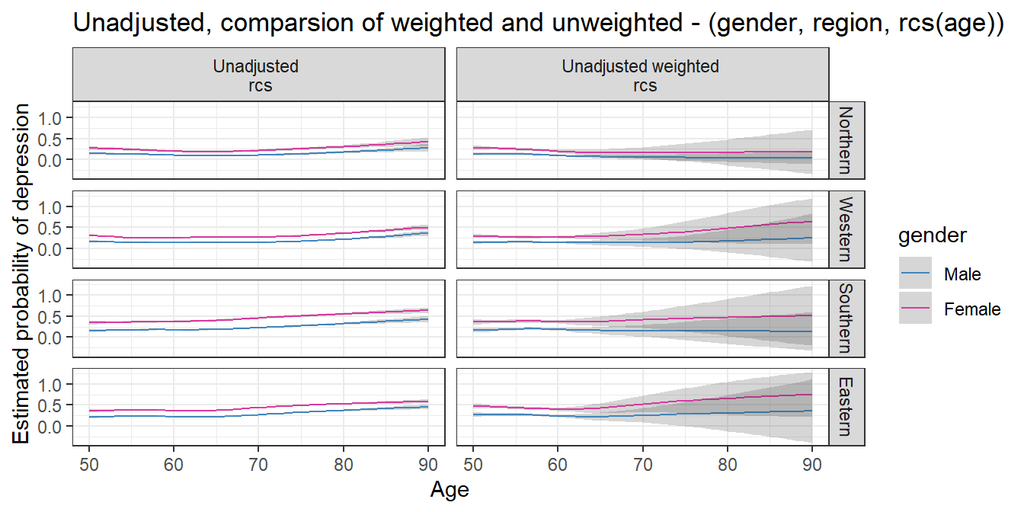

```r
#my.pred.all %>% left_join(select(share.data.w1, starts_with("region")), by="region") %>% ggplot(aes(age1, fit, #color=gender))+ geom_point() + facet_grid(.~regionGroup) + labs(x="Age", y="Estimated probability of depression") + #scale_color_manual(values=c("#4699dd","#ff3db7" ))


#anova(my.mod.w, test="Chi")



ggplot(pred.age_all, aes(age1+50, fit, color=gender)) + geom_line() + facet_grid(region~model) + labs(x="Age", y="Estimated probability of depression") + scale_color_manual(values=c("#4699dd","#ff3db7" )) + ggtitle("Unadjusted, comparsion of weighted and unweighted - (gender, region, rcs(age))") +
  geom_ribbon(aes(ymin = fit - 1.96*se.fit, ymax = fit + 1.96*se.fit), alpha = 0.2, linetype=0) +  theme_bw()
```

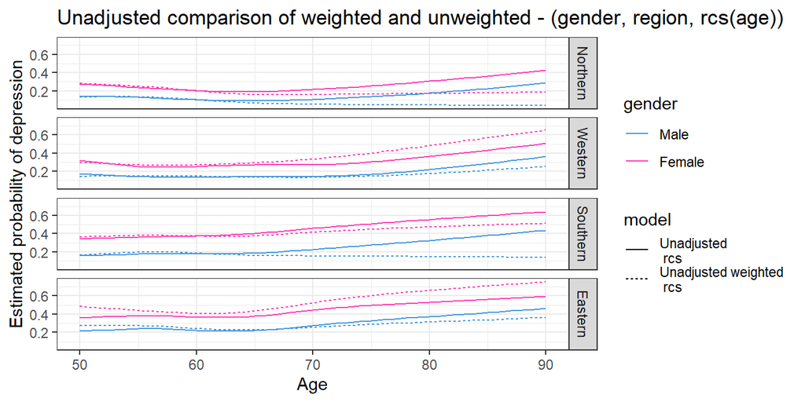

```r
ggplot(pred.age_all, aes(age1+50, fit, color=gender)) + geom_line(aes(linetype=model)) + facet_grid(region~.) + labs(x="Age", y="Estimated probability of depression") + scale_color_manual(values=c("#4699dd","#ff3db7" )) + ggtitle("Unadjusted comparison of weighted and unweighted - (gender, region, rcs(age))") +
 # geom_ribbon(aes(ymin = fit - 1.96*se.fit, ymax = fit + 1.96*se.fit), alpha = 0.2, linetype=0) +
  theme_bw()
```

Using weights greatly increases the variability of the probabilities after age 65, when also the estimated shape of the association between age and probability of depression differs between the models. `

### 1.2.3 Adjusted models - weighted models and comparsion with unweighted

```r
my.mod2  <- glm(
  eurodcat_imp ~
    age1 + age2 + age3 + age4 + gender + region +
    bmi_imp + education_imp + cusmoke_imp + dis_chronic_pres +
    pa_vig + living_arrangement +
    age1:region + age2:region + age3:region + age4:region +
    age1:gender + age2:gender + age3:gender + age4:gender +
    gender:region,
  data = share.data.w1,
  family = "binomial",
  x = TRUE,
  y = TRUE
)



my.mod1  <- glm(
  eurodcat_imp ~
    rcspline.eval(age_int_stand, knots=Knots, inclx = TRUE) + gender + region +
    bmi_imp + education_imp + cusmoke_imp + dis_chronic_pres +
    pa_vig + living_arrangement +
     rcspline.eval(age_int_stand, knots=Knots, inclx = TRUE):region +
     rcspline.eval(age_int_stand, knots=Knots, inclx = TRUE):gender +
    gender:region,
  data = share.data.w1,
  family = "binomial",
  x = TRUE,
  y = TRUE
)



data.grid.adj <- expand.grid(age1=unique(share.data.w1$age1), gender=levels(share.data.w1$gender), region=levels(share.data.w1$region),
                         #overall mean
                         #bmi_10 = mean(share.data.w1$bmi_imp, na.rm=TRUE),

                      education_imp ="Low", cusmoke_imp="No",  dis_chronic_pres="0",
                        pa_vig = "Hardly ever, or never" ,  living_arrangement="Living with partner"
                         )


#using median bmi, separate evaluation by gender

data.grid.adj <- left_join(data.grid.adj,
          share.data.w1 %>% group_by(gender) %>%
            #rename(age1 = age_int_stand) %>%
            summarise(bmi_imp=median(bmi_imp, na.rm=TRUE)),
           by=c("gender"))

data.grid.adj <- left_join(data.grid.adj, age, by="age1")
data.grid.adj.region <- data.grid.adj



#defining also data grid for countries
data.grid.adj.region <- expand.grid(age1=unique(share.data.w1$age1), gender=levels(share.data.w1$gender), region=levels(share.data.w1$region),
                         #overall mean
                         #bmi_10 = mean(share.data.w1$bmi_imp, na.rm=TRUE),

                      education_imp ="Low", cusmoke_imp="No",  dis_chronic_pres="0",
                        pa_vig = "Hardly ever, or never" ,  living_arrangement="Living with partner"
                         )
data.grid.adj.region <- left_join(data.grid.adj.region,
          share.data.w1 %>% group_by(gender) %>%
            #rename(age1 = age_int_stand) %>%
            summarise(bmi_imp=median(bmi_imp, na.rm=TRUE)),
           by=c("gender"))

data.grid.adj.region <- left_join(data.grid.adj.region, age, by="age1")


#derive the predicted probabilities
my.pred <- predict(my.mod2, newdata=data.grid.adj, se.fit = TRUE, type="response")

#join the levels of the covariates and the predicted probabilities
my.pred.all <- cbind.data.frame(data.grid.adj, my.pred)

#saving the estimates from the 2-way models
pred.age_adjusted_region_rcs <- my.pred.all


pred.age_adjusted_region_rcs <- mutate( pred.age_adjusted_region_rcs ,  "education_imp"=NA,      "cusmoke_imp"=NA  ,      "dis_chronic_pres"=NA  ,  "pa_vig" = NA,  "living_arrangement" = NA,  "bmi_imp" = NA,  "age2" = NA        ,       "age3" = NA ,              "age4" = NA    )
pred.age_adjusted_region_rcs<- mutate(pred.age_adjusted_region_rcs, model="Adjusted \n rcs")


pred.age_all <- mutate(pred.age_all,
                     "education_imp"=NA,      "cusmoke_imp"=NA  ,      "dis_chronic_pres"=NA  ,  "pa_vig" = NA,  "living_arrangement" = NA,  "bmi_imp" = NA )



pred.age_all <- rbind.data.frame(pred.age_all, pred.age_adjusted_region_rcs)
```

```r
ggplot(my.pred.all, aes(age1+50, fit, color=gender)) + geom_line() + facet_wrap(region~., ncol=5) + labs(x="Age", y="Estimated probability of depression") + scale_color_manual(values=c("#4699dd","#ff3db7" )) + ggtitle("Adjusted estimates (gender, region, rcs(age))") +
  geom_ribbon(aes(ymin = fit - 1.96*se.fit, ymax = fit + 1.96*se.fit), alpha = 0.2, linetype=0) +  theme_bw()


anova(my.mod1, test="Chi")
```

```r
#to display all the coefficients
#get.OR2(my.mod1)


#kable(get.OR2(my.mod1)[9:19,], digits=2, caption = "Estimated OR from the adjusted rcs model")
#kable(get.OR2(my.mod1)[10:20,], digits=2, caption = "Estimated OR from the adjusted rcs model",     format = "latex")


OR.uw <- get.OR2(my.mod1)[10:20,]
```

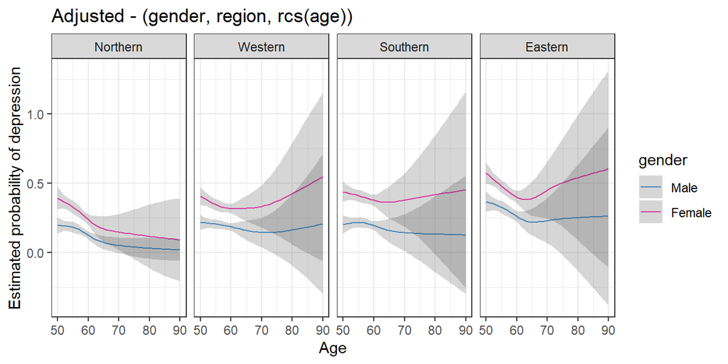

```r
#dstrat <- svydesign(id=~psu,strata=~stratum1, weights=~ cciw_w1,
#data=share.data.w1, nest=TRUE)


 my.mod.w <- svyglm(eurodcat_imp ~
    age1 + age2 + age3 + age4 + gender + region +
    bmi_imp + education_imp + cusmoke_imp + dis_chronic_pres +
    pa_vig + living_arrangement +
    age1:region + age2:region + age3:region + age4:region +
    age1:gender + age2:gender + age3:gender + age4:gender +
    gender:region,
                        design=dstrat, family="binomial",  x=TRUE, y=TRUE)




#derive the predicted probabilities
my.pred <- predict(my.mod.w, newdata=data.grid.adj.region, se.fit = TRUE, type="response")
#join the levels of the covariates and the predicted probabilities
my.pred.all <- cbind.data.frame(data.grid.adj.region, my.pred)

my.pred.all <- pred.age_unadjusted_region_rcs_w<- rename(my.pred.all, fit=response, se.fit = SE)
pred.age_adjusted_region_rcs_w <- mutate(pred.age_unadjusted_region_rcs_w, residual.scale = 1, model = "Adjusted weighted \n rcs")

pred.age_all <- rbind.data.frame(pred.age_all, pred.age_adjusted_region_rcs_w)

#saving the estimates from the 2-way models
pred.age_adjusted_region_rcs_w <- my.pred.all

ggplot(my.pred.all, aes(age1+50, fit, color=gender)) + geom_line() + facet_wrap(region~., ncol=5) + labs(x="Age", y="Estimated probability of depression") + scale_color_manual(values=c("#4699dd","#ff3db7" )) + ggtitle("Adjusted - (gender, region, rcs(age))") +
  geom_ribbon(aes(ymin = fit - 1.96*se.fit, ymax = fit + 1.96*se.fit), alpha = 0.2, linetype=0) +  theme_bw()
```

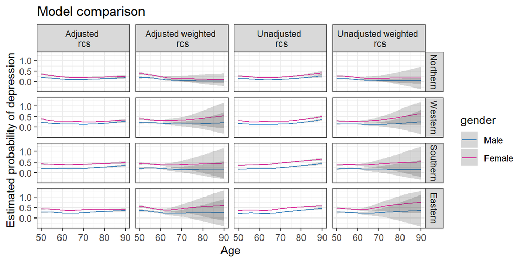

```r
#my.pred.all %>% left_join(select(share.data.w1, starts_with("region")), by="region") %>% ggplot(aes(age1, fit, #color=gender))+ geom_point() + facet_grid(.~regionGroup) + labs(x="Age", y="Estimated probability of depression") + #scale_color_manual(values=c("#4699dd","#ff3db7" ))


#anova(my.mod.w, test="Chi")

pred.age_all$modelAdjUnadj <- pred.age_all$modelWeightedUnw <- pred.age_all$model

level_key <- c(`Unadjusted \n rcs` = "Unadjusted", `Unadjusted weighted \n rcs` = "Unadjusted",
               `Adjusted \n rcs` = "Adjusted", `Adjusted weighted \n rcs` = "Adjusted"
                 )

pred.age_all$modelAdjUnadj <- recode_factor(pred.age_all$modelAdjUnadj, !!!level_key)


level_key <- c(`Unadjusted \n rcs` = "Unweighted", `Unadjusted weighted \n rcs` = "Weighted",
               `Adjusted \n rcs` = "Unweighted", `Adjusted weighted \n rcs` = "Weighted"
                 )

pred.age_all$modelWeightedUnw <- recode_factor(pred.age_all$modelWeightedUnw, !!!level_key)



ggplot(pred.age_all, aes(age1+50, fit, color=gender)) + geom_line() + facet_grid(region~model) + labs(x="Age", y="Estimated probability of depression") + scale_color_manual(values=c("#4699dd","#ff3db7" )) + ggtitle("Model comparison") +
  geom_ribbon(aes(ymin = fit - 1.96*se.fit, ymax = fit + 1.96*se.fit), alpha = 0.2, linetype=0) +  theme_bw()
```

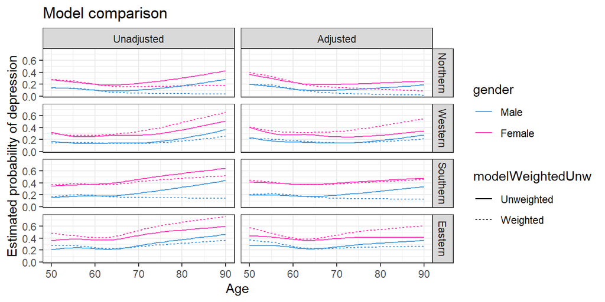

```r
ggplot(pred.age_all, aes(age1+50, fit, color=gender)) + geom_line(aes(linetype=modelWeightedUnw)) + facet_grid(region~modelAdjUnadj) + labs(x="Age", y="Estimated probability of depression") + scale_color_manual(values=c("#4699dd","#ff3db7" )) + ggtitle("Model comparison") +
 # geom_ribbon(aes(ymin = fit - 1.96*se.fit, ymax = fit + 1.96*se.fit), alpha = 0.2, linetype=0) +
  theme_bw()
```

Ajdusting for risk factors furhter decreases the precision of the estimates with weighted data. Similarly to unadjusted analysis, also here the shape of the estimated probabilities differs using or omitting weights.

```r
#to display all the coefficients
#get.OR2(my.mod1)

OR.w <- get.OR2(my.mod.w)[10:20,]

df <- cbind.data.frame(OR.uw, OR.w)

kable(df, digits=2, caption = "Estimated OR from the adjusted  unweighted (leftmost) and weighted (rightmost) rcs model")
```

Estimated OR from the adjusted unweighted (leftmost) and weighted (rightmost) rcs model

|  | OR | 95% CI LL | 95% CI UL | P-value | OR | 95% CI LL | 95% CI UL | P-value |
| --- | --- | --- | --- | --- | --- | --- | --- | --- |
| bmi_imp | 1.00 | 0.99 | 1.00 | 0.72 | 1.00 | 0.99 | 1.01 | 0.74 |
| education_impMedium | 0.74 | 0.70 | 0.78 | 0.00 | 0.68 | 0.62 | 0.74 | 0.00 |
| education_impHigh | 0.60 | 0.56 | 0.64 | 0.00 | 0.55 | 0.48 | 0.62 | 0.00 |
| education_impOther | 1.12 | 0.85 | 1.48 | 0.41 | 1.09 | 0.75 | 1.59 | 0.65 |
| cusmoke_impYes | 1.23 | 1.16 | 1.30 | 0.00 | 1.15 | 1.05 | 1.26 | 0.00 |
| dis_chronic_pres1 | 1.51 | 1.43 | 1.59 | 0.00 | 1.51 | 1.38 | 1.64 | 0.00 |
| dis_chronic_pres2+ | 2.63 | 2.48 | 2.79 | 0.00 | 2.51 | 2.23 | 2.83 | 0.00 |
| pa_vigOnce a week | 1.01 | 0.94 | 1.08 | 0.85 | 0.98 | 0.87 | 1.12 | 0.81 |
| pa_vigOne to three times a month | 1.03 | 0.95 | 1.12 | 0.44 | 1.14 | 1.00 | 1.31 | 0.05 |
| pa_vigHardly ever, or never | 1.78 | 1.69 | 1.88 | 0.00 | 1.80 | 1.64 | 1.98 | 0.00 |
| living_arrangementLiving alone | 1.39 | 1.32 | 1.46 | 0.00 | 1.39 | 1.28 | 1.50 | 0.00 |

```r
#kable(get.OR2(my.mod1)[10:20,], digits=2, caption = "Estimated OR from the adjusted rcs model",     format = "latex")
```

The estimated OR for the risk factors obtained with weighted and unweighted analysis are similar

### 1.2.4 Sensitivity analysis

As we observed big differences between weighted and unweighthed analyses, we remove subjects with large weights and refit the models.

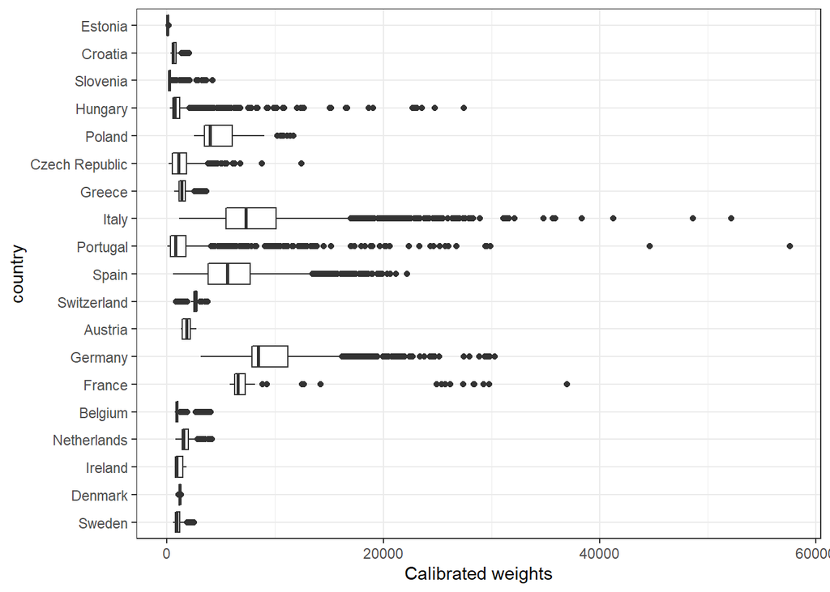

```r
share.data.w1 <- droplevels(share.data.w1)
ggplot(share.data.w1, aes(country, cciw_merged)) +  geom_boxplot() + theme_bw() + labs(y="Calibrated weights") + coord_flip()
```

```r
q98 <- share.data.w1 %>% group_by(country) %>% summarise(q98=quantile(cciw_merged, prob =0.975))

share.data.w1 <- left_join(share.data.w1, q98, by="country")

share.data.w1.sens <- filter(share.data.w1, cciw_merged<q98)


dstrat <- survey::svydesign(id=~psu,strata=~stratum1, weights=~ cciw_merged,
data = share.data.w1, nest=TRUE)

# id=∼psu specifies sampling at primary sampling unit.
# stratum1 is a factor variable for stratum used for sampling, usually geographical units
# share.data.w1 is the data frame with all the data.
# cciw_w1 contains calibrated sampling weights

# remove the participants not used in the analysis - removed because of missing data or exclusion criteria
dstrat <- subset(dstrat, !is.na(eurodcat_imp) & cciw_merged<=q98)
```

#### 1.2.4.1 Unadjusted models - weighted models and comparsion with unweighted

```r
share.data.w1.sens <- filter(share.data.w1, cciw_merged<=q98)


my.mod <- glm(eurodcat_imp ~ rcs(age_int_stand) + gender + region +
                       rcs(age_int_stand):region + rcs(age_int_stand):gender + gender:region ,
                                             data=share.data.w1.sens, family="binomial",  x=TRUE, y=TRUE)

#save the spline terms in the complete data set for further use
share.data.w1.sens <- share.data.w1.sens %>% mutate(age1 = my.mod$x[,2],
                                                                    age2 = my.mod$x[,3],
                                                                    age3 = my.mod$x[,4],
                                                                    age4 = my.mod$x[,5])


# retrieve the location of knots used and assign them to Knots variable
Knots <- Hmisc::rcspline.eval(x = share.data.w1$age_int_stand, nk = 5, knots.only = TRUE)

#reproduces the spline values for age, expands for each integer value from 50 to 90
age = rcspline.eval(c(50:90)-50, knots=Knots)
age <- cbind.data.frame(age1=c(50:90)-50, age )
dimnames(age)[[2]] <- c("age1", "age2", "age3", "age4")






if(!is.null(my.mod$na.action)){
my.mod2 <- glm(eurodcat_imp ~ age1 + age2 + age3 + age4 + gender + region +
                      age1:region + age2:region + age3:region + age4:region +
                       age1:gender + age2:gender + age3:gender + age4:gender +
                       gender:region ,
                        data=share.data.w1.sens[-my.mod$na.action,], family="binomial",  x=TRUE, y=TRUE)} else {
 my.mod2 <- glm(eurodcat_imp ~ age1 + age2 + age3 + age4 + gender + region +
                      age1:region + age2:region + age3:region + age4:region +
                       age1:gender + age2:gender + age3:gender + age4:gender +
                       gender:region ,
                        data=share.data.w1.sens, family="binomial",  x=TRUE, y=TRUE)
}





#derive the data.frame containing the levels of the covariatee, where the probabilities of depression estimated by the model will be derived
data.grid <- expand.grid(age1=age[,1], gender=levels(share.data.w1.sens$gender), region=levels(share.data.w1.sens$region))
data.grid <- left_join(data.grid, age, by="age1" )

#data.grid <- filter(data.grid, is.element(region, c("Austria", "Spain", "Italy", "France", "Belgium", "Israel")))
data.grid.region <- data.grid


#defining also data grid for countries
data.grid.region <- expand.grid(age1=age[,1], gender=levels(share.data.w1.sens$gender), region=levels(share.data.w1.sens$region))
data.grid.region <- left_join(data.grid.region, age, by="age1" )




#derive the predicted probabilities
my.pred <- predict(my.mod2, newdata=data.grid, se.fit = TRUE, type="response")

#join the levels of the covariates and the predicted probabilities
my.pred.all <- cbind.data.frame(data.grid, my.pred)

#saving the estimates from the 2-way models
pred.age_unadjusted_region_rcs <- my.pred.all
```

```r
ggplot(my.pred.all, aes(age1+50, fit, color=gender)) + geom_line() + facet_wrap(region~., ncol=5) + labs(x="Age", y="Estimated probability of depression") + scale_color_manual(values=c("#4699dd","#ff3db7" )) + ggtitle("Unadjusted - (gender, region, rcs(age))") +
  geom_ribbon(aes(ymin = fit - 1.96*se.fit, ymax = fit + 1.96*se.fit), alpha = 0.2, linetype=0) +  theme_bw()


#my.pred.all %>% left_join(select(filter(share.data.w1, cciw_w1<20000), starts_with("region")), by="region") %>% ggplot(aes(age1, fit, #color=gender))+ geom_point() + facet_grid(.~regionGroup) + labs(x="Age", y="Estimated probability of depression") + #scale_color_manual(values=c("#4699dd","#ff3db7" ))


anova(my.mod, test="Chi")
```

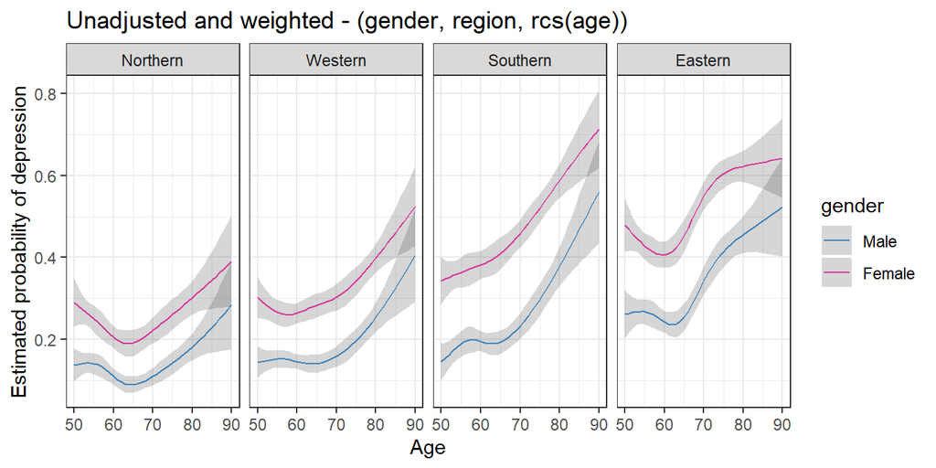

```r
 my.mod.w <- svyglm(eurodcat_imp ~ age1 + age2 + age3 + age4 + gender + region +
                      age1:region + age2:region + age3:region + age4:region +
                       age1:gender + age2:gender + age3:gender + age4:gender +
                       gender:region ,
                        design=dstrat, family="binomial",  x=TRUE, y=TRUE)




#derive the predicted probabilities
my.pred <- predict(my.mod.w, newdata=data.grid, se.fit = TRUE, type="response")
#join the levels of the covariates and the predicted probabilities
my.pred.all <- cbind.data.frame(data.grid, my.pred)

my.pred.all <- pred.age_unadjusted_region_rcs_w<- rename(my.pred.all, fit=response, se.fit = SE)
pred.age_unadjusted_region_rcs_w <- mutate(pred.age_unadjusted_region_rcs_w, residual.scale = 1)

pred.age_all <- rbind.data.frame(pred.age_unadjusted_region_rcs,pred.age_unadjusted_region_rcs_w)
pred.age_all <- mutate(pred.age_all, model=c(rep("Unadjusted \n rcs", nrow(pred.age_unadjusted_region_rcs)), rep("Unadjusted weighted \n rcs", nrow(pred.age_unadjusted_region_rcs))))

#saving the estimates from the 2-way models
pred.age_unadjusted_region_rcs <- my.pred.all




ggplot(my.pred.all, aes(age1+50, fit, color=gender)) + geom_line() + facet_wrap(region~., ncol=5) + labs(x="Age", y="Estimated probability of depression") + scale_color_manual(values=c("#4699dd","#ff3db7" )) + ggtitle("Unadjusted and weighted - (gender, region, rcs(age))") +
  geom_ribbon(aes(ymin = fit - 1.96*se.fit, ymax = fit + 1.96*se.fit), alpha = 0.2, linetype=0) +  theme_bw()
```

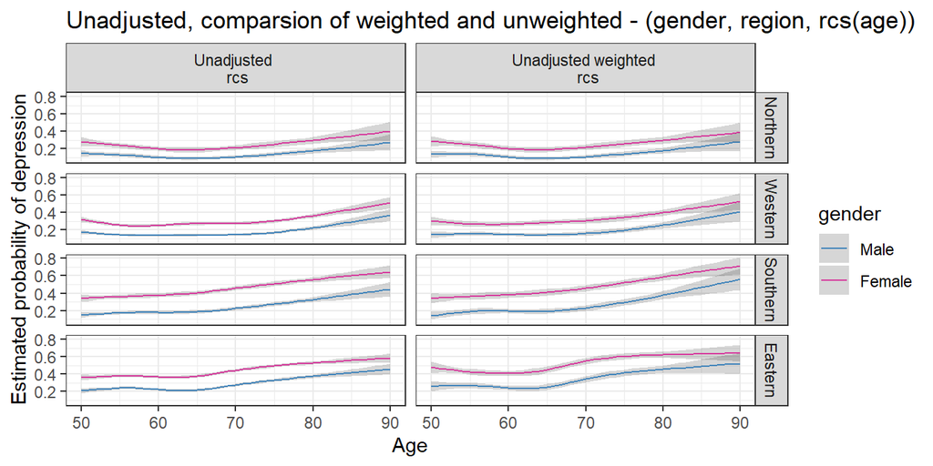

```r
#my.pred.all %>% left_join(select(share.data.w1, starts_with("region")), by="region") %>% ggplot(aes(age1, fit, #color=gender))+ geom_point() + facet_grid(.~regionGroup) + labs(x="Age", y="Estimated probability of depression") + #scale_color_manual(values=c("#4699dd","#ff3db7" ))


#anova(my.mod.w, test="Chi")



ggplot(pred.age_all, aes(age1+50, fit, color=gender)) + geom_line() + facet_grid(region~model) + labs(x="Age", y="Estimated probability of depression") + scale_color_manual(values=c("#4699dd","#ff3db7" )) + ggtitle("Unadjusted, comparsion of weighted and unweighted - (gender, region, rcs(age))") +
  geom_ribbon(aes(ymin = fit - 1.96*se.fit, ymax = fit + 1.96*se.fit), alpha = 0.2, linetype=0) +  theme_bw()
```

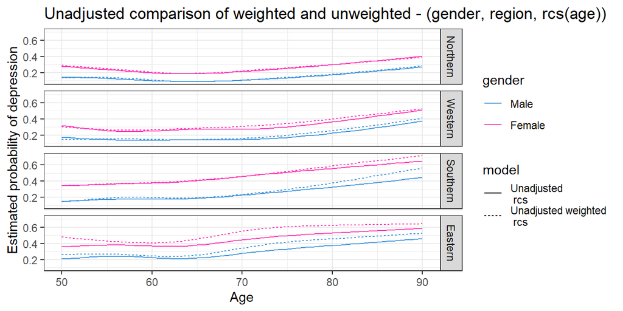

```r
ggplot(pred.age_all, aes(age1+50, fit, color=gender)) + geom_line(aes(linetype=model)) + facet_grid(region~.) + labs(x="Age", y="Estimated probability of depression") + scale_color_manual(values=c("#4699dd","#ff3db7" )) + ggtitle("Unadjusted comparison of weighted and unweighted - (gender, region, rcs(age))") +
 # geom_ribbon(aes(ymin = fit - 1.96*se.fit, ymax = fit + 1.96*se.fit), alpha = 0.2, linetype=0) +
  theme_bw()
```

The removal of the participants with large weights reduced considerably the variability of the estimates and the results obtained using weighted and unweighted regression were more similiar. The largest differences persisted at older ages and in Eastern countries, where the weighted estimates indicated larger probability of depression. `

#### 1.2.4.2 Adjusted models - weighted models and comparsion with unweighted

```r
my.mod2  <- glm(
  eurodcat_imp ~
    age1 + age2 + age3 + age4 + gender + region +
    bmi_imp + education_imp + cusmoke_imp + dis_chronic_pres +
    pa_vig + living_arrangement +
    age1:region + age2:region + age3:region + age4:region +
    age1:gender + age2:gender + age3:gender + age4:gender +
    gender:region,
  data = share.data.w1,
  family = "binomial",
  x = TRUE,
  y = TRUE
)



my.mod1  <- glm(
  eurodcat_imp ~
    rcspline.eval(age_int_stand, knots=Knots, inclx = TRUE) + gender + region +
    bmi_imp + education_imp + cusmoke_imp + dis_chronic_pres +
    pa_vig + living_arrangement +
     rcspline.eval(age_int_stand, knots=Knots, inclx = TRUE):region +
     rcspline.eval(age_int_stand, knots=Knots, inclx = TRUE):gender +
    gender:region,
  data = share.data.w1,
  family = "binomial",
  x = TRUE,
  y = TRUE
)



data.grid.adj <- expand.grid(age1=unique(share.data.w1$age1), gender=levels(share.data.w1$gender), region=levels(share.data.w1$region),
                         #overall mean
                         #bmi_10 = mean(share.data.w1$bmi_imp, na.rm=TRUE),

                      education_imp ="Low", cusmoke_imp="No",  dis_chronic_pres="0",
                        pa_vig = "Hardly ever, or never" ,  living_arrangement="Living with partner"
                         )


#using median bmi, separate evaluation by gender

data.grid.adj <- left_join(data.grid.adj,
          share.data.w1 %>% group_by(gender) %>%
            #rename(age1 = age_int_stand) %>%
            summarise(bmi_imp=median(bmi_imp, na.rm=TRUE)),
           by=c("gender"))

data.grid.adj <- left_join(data.grid.adj, age, by="age1")
data.grid.adj.region <- data.grid.adj



#defining also data grid for countries
data.grid.adj.region <- expand.grid(age1=unique(share.data.w1$age1), gender=levels(share.data.w1$gender), region=levels(share.data.w1$region),
                         #overall mean
                         #bmi_10 = mean(share.data.w1$bmi_imp, na.rm=TRUE),

                      education_imp ="Low", cusmoke_imp="No",  dis_chronic_pres="0",
                        pa_vig = "Hardly ever, or never" ,  living_arrangement="Living with partner"
                         )
data.grid.adj.region <- left_join(data.grid.adj.region,
          share.data.w1 %>% group_by(gender) %>%
            #rename(age1 = age_int_stand) %>%
            summarise(bmi_imp=median(bmi_imp, na.rm=TRUE)),
           by=c("gender"))

data.grid.adj.region <- left_join(data.grid.adj.region, age, by="age1")


#derive the predicted probabilities
my.pred <- predict(my.mod2, newdata=data.grid.adj, se.fit = TRUE, type="response")

#join the levels of the covariates and the predicted probabilities
my.pred.all <- cbind.data.frame(data.grid.adj, my.pred)

#saving the estimates from the 2-way models
pred.age_adjusted_region_rcs <- my.pred.all


pred.age_adjusted_region_rcs <- mutate( pred.age_adjusted_region_rcs ,  "education_imp"=NA,      "cusmoke_imp"=NA  ,      "dis_chronic_pres"=NA  ,  "pa_vig" = NA,  "living_arrangement" = NA,  "bmi_imp" = NA,  "age2" = NA        ,       "age3" = NA ,              "age4" = NA    )
pred.age_adjusted_region_rcs<- mutate(pred.age_adjusted_region_rcs, model="Adjusted \n rcs")


pred.age_all <- mutate(pred.age_all,
                     "education_imp"=NA,      "cusmoke_imp"=NA  ,      "dis_chronic_pres"=NA  ,  "pa_vig" = NA,  "living_arrangement" = NA,  "bmi_imp" = NA )



pred.age_all <- rbind.data.frame(pred.age_all, pred.age_adjusted_region_rcs)
```

```r
ggplot(my.pred.all, aes(age1+50, fit, color=gender)) + geom_line() + facet_wrap(region~., ncol=5) + labs(x="Age", y="Estimated probability of depression") + scale_color_manual(values=c("#4699dd","#ff3db7" )) + ggtitle("Adjusted estimates (gender, region, rcs(age))") +
  geom_ribbon(aes(ymin = fit - 1.96*se.fit, ymax = fit + 1.96*se.fit), alpha = 0.2, linetype=0) +  theme_bw()


anova(my.mod1, test="Chi")
```

```r
#to display all the coefficients
#get.OR2(my.mod1)


#kable(get.OR2(my.mod1)[9:19,], digits=2, caption = "Estimated OR from the adjusted rcs model")
#kable(get.OR2(my.mod1)[10:20,], digits=2, caption = "Estimated OR from the adjusted rcs model",     format = "latex")


OR.uw <- get.OR2(my.mod1)[10:20,]
```

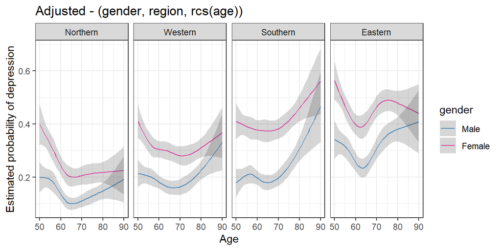

```r
#dstrat <- svydesign(id=~psu,strata=~stratum1, weights=~ cciw_w1,
#data=share.data.w1, nest=TRUE)


 my.mod.w <- svyglm(eurodcat_imp ~
    age1 + age2 + age3 + age4 + gender + region +
    bmi_imp + education_imp + cusmoke_imp + dis_chronic_pres +
    pa_vig + living_arrangement +
    age1:region + age2:region + age3:region + age4:region +
    age1:gender + age2:gender + age3:gender + age4:gender +
    gender:region,
                        design=dstrat, family="binomial",  x=TRUE, y=TRUE)




#derive the predicted probabilities
my.pred <- predict(my.mod.w, newdata=data.grid.adj.region, se.fit = TRUE, type="response")
#join the levels of the covariates and the predicted probabilities
my.pred.all <- cbind.data.frame(data.grid.adj.region, my.pred)

my.pred.all <- pred.age_unadjusted_region_rcs_w<- rename(my.pred.all, fit=response, se.fit = SE)
pred.age_adjusted_region_rcs_w <- mutate(pred.age_unadjusted_region_rcs_w, residual.scale = 1, model = "Adjusted weighted \n rcs")

pred.age_all <- rbind.data.frame(pred.age_all, pred.age_adjusted_region_rcs_w)

#saving the estimates from the 2-way models
pred.age_adjusted_region_rcs_w <- my.pred.all

ggplot(my.pred.all, aes(age1+50, fit, color=gender)) + geom_line() + facet_wrap(region~., ncol=5) + labs(x="Age", y="Estimated probability of depression") + scale_color_manual(values=c("#4699dd","#ff3db7" )) + ggtitle("Adjusted - (gender, region, rcs(age))") +
  geom_ribbon(aes(ymin = fit - 1.96*se.fit, ymax = fit + 1.96*se.fit), alpha = 0.2, linetype=0) +  theme_bw()
```

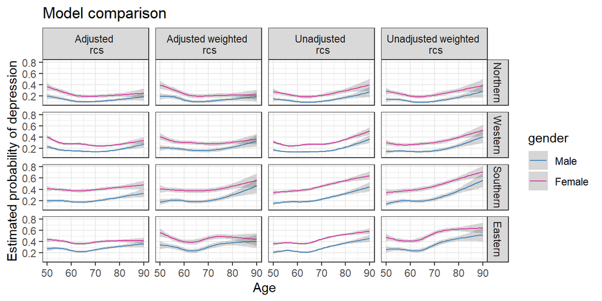

```r
#my.pred.all %>% left_join(select(share.data.w1, starts_with("region")), by="region") %>% ggplot(aes(age1, fit, #color=gender))+ geom_point() + facet_grid(.~regionGroup) + labs(x="Age", y="Estimated probability of depression") + #scale_color_manual(values=c("#4699dd","#ff3db7" ))


#anova(my.mod.w, test="Chi")

pred.age_all$modelAdjUnadj <- pred.age_all$modelWeightedUnw <- pred.age_all$model

level_key <- c(`Unadjusted \n rcs` = "Unadjusted", `Unadjusted weighted \n rcs` = "Unadjusted",
               `Adjusted \n rcs` = "Adjusted", `Adjusted weighted \n rcs` = "Adjusted"
                 )

pred.age_all$modelAdjUnadj <- recode_factor(pred.age_all$modelAdjUnadj, !!!level_key)


level_key <- c(`Unadjusted \n rcs` = "Unweighted", `Unadjusted weighted \n rcs` = "Weighted",
               `Adjusted \n rcs` = "Unweighted", `Adjusted weighted \n rcs` = "Weighted"
                 )

pred.age_all$modelWeightedUnw <- recode_factor(pred.age_all$modelWeightedUnw, !!!level_key)



ggplot(pred.age_all, aes(age1+50, fit, color=gender)) + geom_line() + facet_grid(region~model) + labs(x="Age", y="Estimated probability of depression") + scale_color_manual(values=c("#4699dd","#ff3db7" )) + ggtitle("Model comparison") +
  geom_ribbon(aes(ymin = fit - 1.96*se.fit, ymax = fit + 1.96*se.fit), alpha = 0.2, linetype=0) +  theme_bw()
```

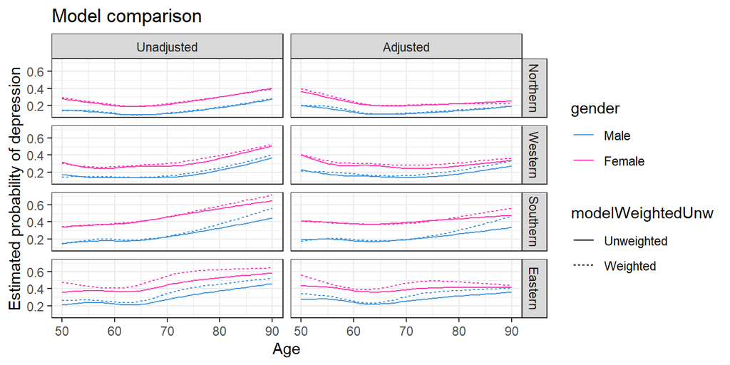

```r
ggplot(pred.age_all, aes(age1+50, fit, color=gender)) + geom_line(aes(linetype=modelWeightedUnw)) + facet_grid(region~modelAdjUnadj) + labs(x="Age", y="Estimated probability of depression") + scale_color_manual(values=c("#4699dd","#ff3db7" )) + ggtitle("Model comparison") +
 # geom_ribbon(aes(ymin = fit - 1.96*se.fit, ymax = fit + 1.96*se.fit), alpha = 0.2, linetype=0) +
  theme_bw()
```

Also in the adjusted analysis the variability was greatly reduced by removing the participants with large weights. The estimated shapes of the association between age and probability of depression were similar using weights or omitting them. Some differences were observed for the estimates obtained for the oldest participants, where the variability is the largest, especially in Souther Region. Also with the adjusted analysis the estimated probability of depression in the Eastern region was larger using weights, but the difference was attenuated compared to the unadjusted analysis.

```r
#to display all the coefficients
#get.OR2(my.mod1)

OR.w <- get.OR2(my.mod.w)[10:20,]

df <- cbind.data.frame(OR.uw, OR.w)

kable(df, digits=2, caption = "Estimated OR from the adjusted  unweighted (leftmost) and weighted (rightmost) rcs model")
```

Estimated OR from the adjusted unweighted (leftmost) and weighted (rightmost) rcs model

|  | OR | 95% CI LL | 95% CI UL | P-value | OR | 95% CI LL | 95% CI UL | P-value |
| --- | --- | --- | --- | --- | --- | --- | --- | --- |
| bmi_imp | 1.00 | 0.99 | 1.00 | 0.72 | 1.00 | 0.99 | 1.01 | 0.99 |
| education_impMedium | 0.74 | 0.70 | 0.78 | 0.00 | 0.70 | 0.64 | 0.76 | 0.00 |
| education_impHigh | 0.60 | 0.56 | 0.64 | 0.00 | 0.54 | 0.48 | 0.61 | 0.00 |
| education_impOther | 1.12 | 0.85 | 1.48 | 0.41 | 1.03 | 0.71 | 1.50 | 0.88 |
| cusmoke_impYes | 1.23 | 1.16 | 1.30 | 0.00 | 1.16 | 1.05 | 1.27 | 0.00 |
| dis_chronic_pres1 | 1.51 | 1.43 | 1.59 | 0.00 | 1.54 | 1.42 | 1.68 | 0.00 |
| dis_chronic_pres2+ | 2.63 | 2.48 | 2.79 | 0.00 | 2.58 | 2.30 | 2.88 | 0.00 |
| pa_vigOnce a week | 1.01 | 0.94 | 1.08 | 0.85 | 0.99 | 0.87 | 1.11 | 0.83 |
| pa_vigOne to three times a month | 1.03 | 0.95 | 1.12 | 0.44 | 1.17 | 1.02 | 1.34 | 0.02 |
| pa_vigHardly ever, or never | 1.78 | 1.69 | 1.88 | 0.00 | 1.81 | 1.65 | 1.99 | 0.00 |
| living_arrangementLiving alone | 1.39 | 1.32 | 1.46 | 0.00 | 1.40 | 1.29 | 1.51 | 0.00 |

```r
#kable(get.OR2(my.mod1)[10:20,], digits=2, caption = "Estimated OR from the adjusted rcs model",     format = "latex")
```

The estimated OR for the risk factors with weighted and unweighted analyses were mostly similar, the weighted analysis had larger variability in the estimates.

Omitting the participants with large weights led to results that were very comparable with weighted and unweighted analyses, and there is no important difference in the conclusions that would be drawn from the two analyses, with the exeption of the results that refer to the Eastern region, where the probabilities estimated by the weighted model were larger, even after adjusting for the risk factors.

## 1.3 Analysis of first interviews

For the analysis of first interviews, where we combine the data from different waves, the study weights have to be scaled so that they would add up to the population total in each wave. The distribution of first interviews across waves is quite heterogeneous, as it can be seen in the table below.

```r
table(share.data.first.interview$Wave)
```

```
##
## Wave 1 Wave 2 Wave 4 Wave 5 Wave 6 Wave 7
##  25069  13710  33871  20604  10807      8
```

```r
addmargins(table(share.data.first.interview$country, share.data.first.interview$Wave))
```

```
##
##                  Wave 1 Wave 2 Wave 4 Wave 5 Wave 6 Wave 7    Sum
##   Sweden           2792    589     75   2510     95      0   6061
##   Denmark          1476   1232    423   1810    257      0   5198
##   Ireland             0    952      0      0      0      0    952
##   Netherlands      2696    767    754   1667      0      0   5884
##   Belgium          3459    284   2659   1350   1007      1   8760
##   Luxembourg          0      0      0   1520    423      0   1943
##   France           2665    811   3249    167    326      0   7218
##   Germany          2810    919     27   4266     62      0   8084
##   Austria          1428     56   4011    122     21      0   5638
##   Switzerland       882    700   2449     86     36      0   4153
##   Spain            2012    731   1598   2970    145      2   7458
##   Portugal            0      0   1753      0    126      0   1879
##   Italy            2375   1105   1344   1697   1179      0   7700
##   Greece           2474    802      0      0   2432      3   5711
##   Czech Republic      0   2497   3775   1374     87      1   7734
##   Poland              0   2265    123      0    349      1   2738
##   Hungary             0      0   2821      0      0      0   2821
##   Slovenia            0      0   2545    897   1397      0   4839
##   Croatia             0      0      0      0   2312      0   2312
##   Estonia             0      0   6265    168    553      0   6986
##   Sum             25069  13710  33871  20604  10807      8 104069
```

An additional problem is that only a subset of participants have their first interview in a certain wave (this subset is usually younger compared to the participants that were included previously), and their cross-sectional weights should be rescaled, taking the composition of the sample into account. As the number of first interviews in some waves and countries is very small, we expect that in these instances the rescaling might produce very large and very imprecise weights.

```r
# retrieval of weights for all waves
share.data.weights.all <- f_readRShare(
  datadir = "sharedata",
  waves = c(1,2,4,5,6),
  modules = c("gv_weights", "cv_r"),
  modules.wX = NULL  ,
  countries = NULL,
  variables.in.modules = list(gv_weights = NULL, cv_r = c("age_int", "gender", "yrbirth")),
  keep.module.name.in.vars = FALSE,
  verbose = FALSE
)$df.w


SD.joined <- left_join(share.data.first.interview, share.data.weights.all, by=c("mergeid", "Wave"))

SD.joined <- mutate(SD.joined,
              cciw= case_when(
         Wave=="Wave 1" ~ cciw_w1,
         Wave=="Wave 2" ~ cciw_w2,
         Wave=="Wave 4" ~ cciw_w4,
         Wave=="Wave 5" ~ cciw_w5,
         Wave=="Wave 6" ~ cciw_w6

            ))


country.levels <- levels(SD.joined$country.x)

for (my.country in country.levels) {
      # filter the country specific data
      tmpG <- filter(SD.joined , country.x == my.country)


       m <- tmpG %>% group_by(categoryAgeGenderW, .drop=FALSE)  %>% select(starts_with("cciw_w")) %>% summarise_all(sum, na.rm=TRUE) %>% as.data.frame()
               m <- m[1:num.levels,]
               m$sumcc<- apply(m[,-1], 1, sum)

}
```